# Encontros românticos

Gileade Kelvin

15 de agosto de 2017

```r
library(tidyverse)
library(modelr)
library(broom)
library(GGally)
library(ggfortify)
library(DT)
library(readr)
theme_set(theme_bw())
```

```r
speed_dating <- read_csv("speed-dating.csv")
```

Na análise de hoje iremos utilizar um conjunto de dados que descrevem encontros relâmpagos realizados por pessoas nos EUA. Ao final de cada encontro os integrantes respondiam a um formulário sobre diversas características próprias e principalmente da pessoa com quem o encontro aconteceu. A base de dados pode ser encontrada [aqui](https://github.com/nazareno/ciencia-de-dados-1/tree/master/5-regressao/speed-dating), como existem muitas variáveis, escolherei apenas algumas delas para que possamos primeiramente ter um panorama de geral de como os dados se apresentam e posteriormente utilizar regressão para obter modelos que possam descrever o comportamento dos dados e responder a algumas perguntas interessantes.

### Sobre os dados

Para responder as perguntas contidas nesse post, estamos interessados em observar a priori três variáveis-independentes (shar, attr, fun) e uma variável dependente (like).

**shar:** O quanto uma pessoa acha que compartilhou interesses e hobbies com outra pessoa. Ou seja, o quão comum são os interesses entre as duas pessoas do encontro. **attr:** O quanto uma pessoa acha a outra atraente. **fun:** O quanto uma pessoa acha a outra divertida.

**like:** O quanto uma pessoa gostou da outra.

Em todas essas variáveis os valores possíveis são os números inteiros entre 1 e 10. Optei por remover as observações de encontros nas quais não foram preenchidas alguma dessas variáveis.

```r
encontros <- speed_dating %>%
  select(shar, attr, fun, like) %>%
  na.omit()
```

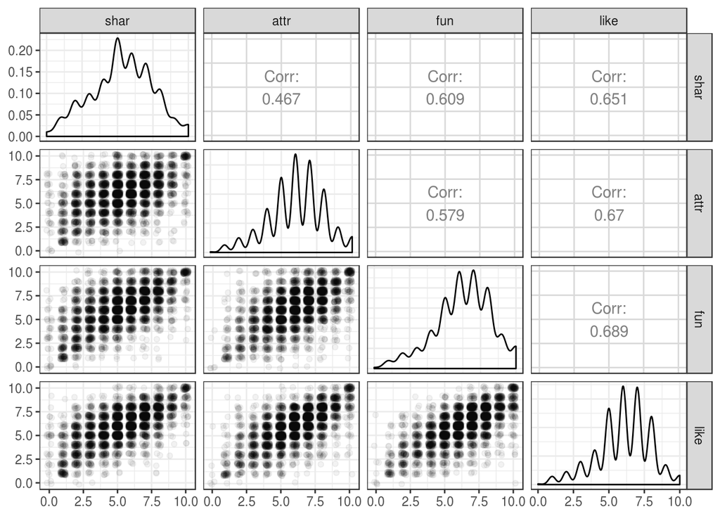

```r
jitter <- function(data, mapping){
  p <- ggplot(data = data, mapping = mapping) +
    geom_jitter(alpha = .05)
  p
}

encontros %>%
  ggpairs(lower = list(continuous = jitter))
```

Como podemos observar no gráfico acima, a correlação entre as variáveis escolhidas (shar, attr, fun) e a variável resposta é alta em todos os casos. A visualização do gráfico de dispersão mostra, que como os valores possíveis são inteiros, a faixa central, mais escura denota a relação entre os pares de variáveis. Para as 3 variáveis de entrada com a variável like observamos uma tendência de subida na dispersão dos pontos, ou seja, quando as variáveis aumentam de valor a variável like também aumenta.

É importante enfatizar que correlação não implica causalidade.

### Será que ser atraente, compartilhar interesses e ser divertido influencia o quanto alguém pode gostar de você?

Agora que já conhecemos as variáveis que iremos trabalhar e como elas se relacionam, podemos responder a essa pergunta utilizando regressão e considerando o efeito das variáveis shar, attr e fun na variável like.

```r
model.encontros = lm(like ~ shar + attr + fun, data = encontros)

encontros_augmented = encontros %>%
  add_predictions(model.encontros) %>%
  add_residuals(model.encontros)
```

Podemos observar os resíduos do modelo para cada preditor (variável-independente escolhida):

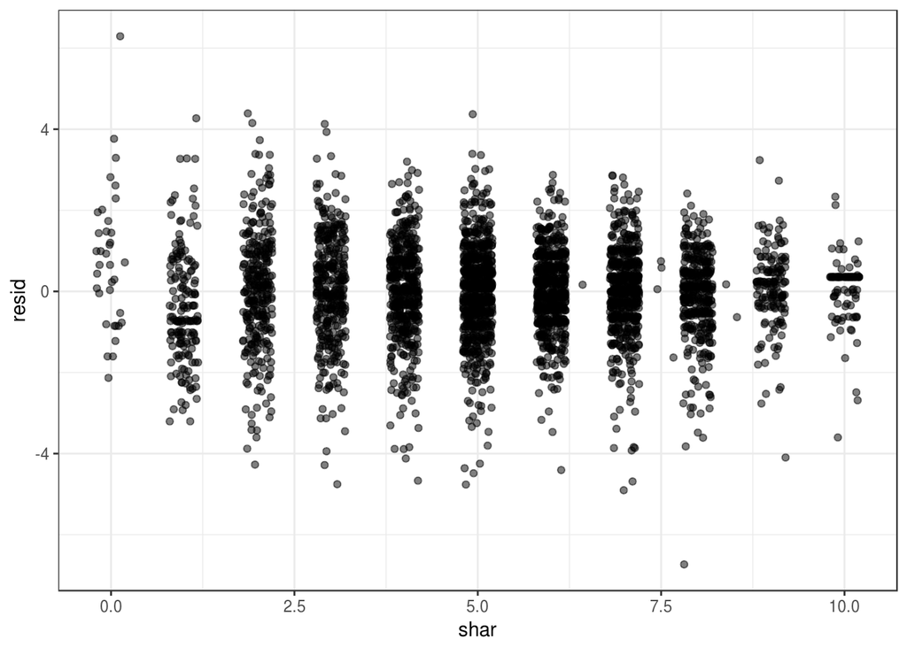

```r
encontros_augmented %>%
  ggplot(aes(x = shar)) +
  geom_jitter(aes(y = resid), alpha = .5)
```

Como é possível observar, para a maioria das observações o modelo descreveu bem os dados com a exceção de alguns pontos que ultrapassaram a diferença de 4 entre a predição e a medida real. No entanto esse é o efeito de resíduo considerando apenas a variável shar.

Se considerarmos as demais variáveis isoladamente temos:

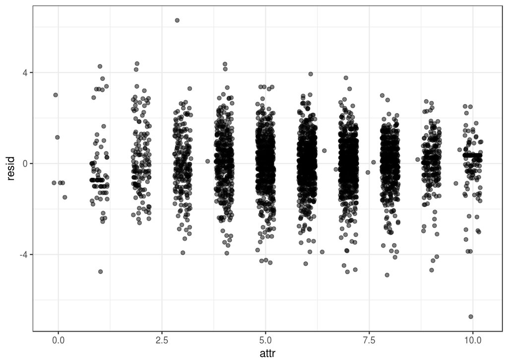

```r
encontros_augmented %>%
  ggplot(aes(x = attr)) +
  geom_jitter(aes(y = resid), alpha = .5)
```

O resultado é semelhante ao encontrado na variável shar.

E por último:

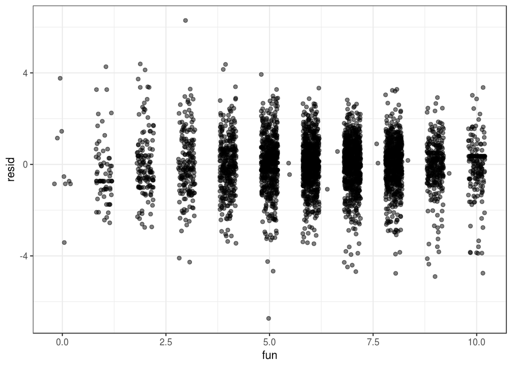

```r
encontros_augmented %>%
  ggplot(aes(x = fun)) +
  geom_jitter(aes(y = resid), alpha = .5)
```

Também encontramos grande parte das observações com resíduo próximo a 0. O que pode indicar que o modelo está descrevendo bem os dados.

Agora que já conhecemos os resíduos gerados pelo nosso modelo para cada variável preditora individualmente podemos examinar os coeficientes e o modelo.

```r
datatable(tidy(model.encontros, conf.int = TRUE) %>%
  select(-std.error, -p.value), class = 'cell-border stripe')
```

|  | term | estimate | statistic | conf.low | conf.high |
| --- | --- | --- | --- | --- | --- |
| 1 | (Intercept) | 0.851179359529435 | 13.4840182899304 | 0.727421210617129 | 0.97493750844174 |
| 2 | shar | 0.260654222073847 | 25.7211590616226 | 0.240786582031569 | 0.280521862116125 |
| 3 | attr | 0.340566325089231 | 30.9681525440358 | 0.319005843389427 | 0.362126806789035 |
| 4 | fun | 0.278113116039977 | 23.3473299671908 | 0.254759383407236 | 0.301466848672718 |

Os coeficientes estimados para as variáveis shar, attr e fun são respectivamente **0.26**, **0.34** e **0.27** respectivamente. Ou seja, é possível afirmar que quando essas três variáveis aumentam a variável-resposta like também aumenta.

Se considerarmos os intervalos com 95% de confiança, percebemos que para todas as variáveis o intervalo não contêm o 0, portanto a estimativa do coeficiente para as variáveis é significativa.

Se levarmos em conta a interpretação individual de cada coeficiente podemos chegar a conclusão que: quando se aumenta 1 unidade na variável shar (nível de interesses em comum) então a variável like (o quanto gostei de alguém) aumenta em ~0.26 unidade. O mesmo ocorre para attr, em que 1 unidade aumenta 0.34 de like, e para fun em que 1 unidade aumenta 0.27 de like. Segundo a estimativa dentre essas três variáveis, a que mais influencia a variável like é a attr, o quanto alguém é atraente.

Só nos últimos parágrafos apresentei como o modelo se comporta com relação a significância, relevância, e magnitude dos coeficientes. Agora vamos entender mais um pouco sobre o modelo e mais especificamente sobre o R quadrado.

```r
datatable(glance(model.encontros) %>% select(r.squared, adj.r.squared, sigma, statistic, p.value), class = 'cell-border stripe')
```

|  | r.squared | adj.r.squared | sigma | statistic | p.value |
| --- | --- | --- | --- | --- | --- |
| 1 | 0.640933573568957 | 0.640679577040003 | 1.11425968866939 | 2523.39500940778 | 0 |

O R quadrado é uma medida de ajustamento de um modelo estatístico linear. Ele indica o quanto o modelo consegue explicar dos dados observados. O nosso modelo, considerando as três variáveis, consegue explicar 64.09 % da variação observada para a variável like!

Respondendo a pergunta inicial (*Será que ser atraente, compartilhar interesses e ser divertido influencia o quanto alguém pode gostar de você?*) podemos afirmar que 64.09 % da variação do gostar de alguém pode ser explicado por essas variáveis!

```r
model_plot = encontros %>%
  data_grid(shar = seq_range(shar, 10),
            attr = seq_range(attr, 4),
            fun = seq_range(fun, 3)) %>%
  add_predictions(model.encontros)
```

Abaixo podemos visualizar o modelo e como as variáveis (shar, attr, fun) influenciam a variável like.

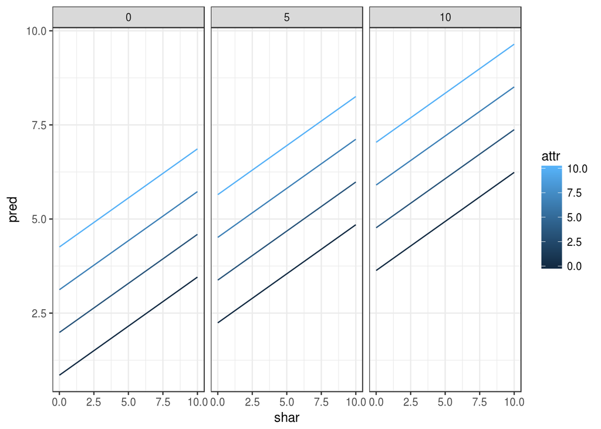

```r
model_plot %>%
  ggplot(aes(x = shar, y = pred)) +
  geom_line(aes(group = attr, colour = attr)) +
  facet_grid(. ~ fun)
```

### Será que o efeito de ser atraente em gostar de alguém muda quando quem avalia é homem ou mulher?

Para responder essa pergunta iremos atrelar o efeito que ser atraente causa em gostar de alguem quando quem avalia é mulher ou não. Para isso utilizaremos o seguinte modelo de regressão linear:

```r
encontros_gender <- speed_dating %>%
  select(gender, attr, like) %>%
  mutate(gen = if_else(gender == 0, TRUE, FALSE)) %>%
  na.omit()
```

```r
model.gender.encontros <- lm(like ~ gen * attr, data = encontros_gender)
```

```r
model.gender.augment = encontros_gender %>%
  add_predictions(model.gender.encontros) %>%
  add_residuals(model.gender.encontros)
```

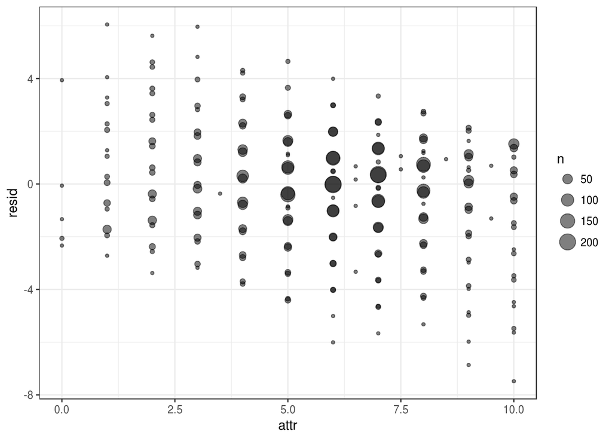

```r
model.gender.augment %>%
  ggplot(aes(x = attr)) +
  geom_count(aes(y = resid), alpha = .5)
```

Os resíduos do modelo parecem estar concetrados na faixa entre -4 e 4, se considerarmos que a variável like vai de 1 até 10, é considerável o número de observações que o modelo não explica. No entanto somente essa visualização não pode nos dizer muito sobre o modelo, precisamos de mais dados estatísticos para poder embasar alguma conclusão com mais confiança.

```r
datatable(tidy(model.gender.encontros, conf.int = TRUE) %>%
  select(-std.error, -p.value), class = 'cell-border stripe')
```

|  | term | estimate | statistic | conf.low | conf.high |
| --- | --- | --- | --- | --- | --- |
| 1 | (Intercept) | 2.33552042538686 | 23.489521695083 | 2.14059542341161 | 2.53044542736211 |
| 2 | genTRUE | -0.27192645963155 | -2.06618260456436 | -0.529939002264036 | -0.0139139169990647 |
| 3 | attr | 0.614595294633493 | 40.8260710057994 | 0.585082543513495 | 0.644108045753491 |
| 4 | genTRUE:attr | 0.0428418746502693 | 2.0791767550386 | 0.00244617763983374 | 0.0832375716607049 |

Ufa! No parágrafo anterior falamos de relevância, significância e magnitude das variáveis preditoras. Mas e sobre o quanto nosso modelo representa da variação dos dados? O que podemos dizer?

```r
datatable(glance(model.gender.encontros) %>% select(r.squared, adj.r.squared, sigma, statistic, p.value), class = 'cell-border stripe')
```

|  | r.squared | adj.r.squared | sigma | statistic | p.value |
| --- | --- | --- | --- | --- | --- |
| 1 | 0.451226349148863 | 0.450882002578573 | 1.37274566795844 | 1310.38432811947 | 0 |

Cerca de 45.12 % da variação das observações pode ser observada adotando esse modelo.

Por hoje é só! Até a próxima análise!!!